# Google Apps 商店的数据分析

## / 简介

相信大家对移动应用商店都不陌生吧。Google Play Store（Google Play商店）是谷歌官方的软件应用商店，拥有上架软件数十万款，下载量更是突破了20亿次，为了手机用户提供了极为广泛的应用选择，很受大家的欢迎。

本数据集(googleplaystore.csv)包含了 Google Play 商店中 App 的数据。该数据是Kaggle中 [Google Play Store Apps](https://www.kaggle.com/lava18/google-play-store-apps) 的一部分，其中包含 Google Play 商店中 10k+ 应用软件的信息。

数据中的变量含义解释：

```
App: 应用的名称，字符变量。
Category: 应用所属的分类，字符变量。
Rating: 某应用的用户评分，数值变量。
Reviews: 某应用获得的用户评论数量，数值变量。
Size: 某应用的所占存储空间的大小，字符变量。
Installs: 用户安装和下载某应用的次数，字符变量。
Type: 付费或免费，分类变量。
Price: 价格，字符变量。
Content Rating: 应用商店针对内容给出的年龄评级组 - Children / Mature 21+ / Adult，分类变量。
Genres: 类型/流派，一个应用可以属于多个流派，比如音乐、游戏、家庭等，字符变量。
Last Updated: 应用最新更新的日期，字符变量。
Current Ver: 当前应用的版本，字符变量。
Android Ver: 安装该应用所需要的最低安卓版本，字符变量。
```

## / 项目完成指南

本项目中的数据分析流程已经给出，但代码将完全由你自己进行书写，如果你无法完成本项目，说明你目前的能力并不足以完成 数据分析(进阶)纳米学位，建议先进行 数据分析（入门）纳米学位的学习，掌握进阶课程的先修知识。

对于数据分析过程的记录也是数据分析报告的一个重要部分，你可以自己在需要的位置插入Markdown cell，记录你在数据分析中的关键步骤和推理过程。比如：数据有什么样的特点，统计数据的含义是什么，你从可视化中可以得出什么结论，下一步分析是什么，为什么执行这种分析。如果你无法做到这一点，你也无法通过本项目。

> **小贴士**: 像这样的引用部分旨在为学员提供实用指导，帮助学员了解并使用 Jupyter notebook

## / 提出问题

在此项目中，你将以一名数据分析师的身份执行数据的探索性分析。你将了解数据分析过程的基本流程。在你分析数据之前，请先思考几个你需要了解的关于 Google 商店中应用的问题，例如，最受欢迎（下载量最高）的 Apps 有什么特征？哪些 App 的评分更高？

**问题**：请写下你感兴趣的问题，请确保这些问题能够由现有的数据进行回答。 （为了确保学习的效果，请确保你的数据分析报告中能够包含2幅可视化和1个相关性分析。）

**答案**：

1. 下载分类最多的是什么类型的软件
2. 评论(下载)最多的是什么软件(下载为分类信息,改为考察评论)
3. 免费软件和付费软件的对比
4. 软件评分与Reviews数量有没有关系

在提出了问题之后，我们将开始导入数据，并对数据进行探索性分析，来回答上面提出的问题。

> **小贴士**: 双击上框，文本就会发生变化，所有格式都会被清除，以便你编辑该文本块。该文本块是用 [Markdown](http://daringfireball.net/projects/markdown/syntax)编写的，该语言使用纯文本语法，能用页眉、链接、斜体等来规范文本格式。在纳米学位课程中，你也会用到 Markdown。编辑后，可使用 **Shift** + **Enter** 或 **Shift** + **Return** 运行上该框，使其呈现出编辑好的文本格式。

# 数据评估和清理

## / 了解数据

> **小贴士**: 运行代码框的方法与编辑上方的 Markdown 框的格式类似，你只需点击代码框，按下键盘快捷键 **Shift** + **Enter** 或 **Shift** + **Return** ，或者你也可先选择代码框，然后点击工具栏的 **运行** 按钮来运行代码。运行代码框时，相应单元左侧的信息会出现星号，即 `In [*]:`，若代码执行完毕，星号则会变为某个数字，如 `In [1]`。如果代码运行后有输出结果，输出将会以 `Out [1]:` 的形式出现，其中的数字将与 "In" 中的数字相对应。

```python
# 请先运行此代码块，以确保在可视化中可以显示中文
!rm -rf ~/.cache/matplotlib/fontList.json
!wget http://d.xiazaiziti.com/en_fonts/fonts/s/SimHei.ttf -O /opt/conda/lib/python3.6/site-packages/matplotlib/mpl-data/fonts/ttf/SimHei.ttf
import matplotlib.pyplot as plt

plt.rcParams['font.sans-serif']=['SimHei'] #用来正常显示中文标签
plt.rcParams['axes.unicode_minus']=False #用来正常显示负号
```

```
/bin/sh: wget: command not found
```

```python
# TO DO: load pacakges
import pandas as pd
import pprint as pp
import matplotlib.pyplot as plt
import seaborn as sns

%matplotlib inline
```

```python
# TO DO: load the dataset
df = pd.read_csv('googleplaystore.csv')
```

```python
# TO DO: check the dataset general info
df.info()
```

```
<class 'pandas.core.frame.DataFrame'>
RangeIndex: 10841 entries, 0 to 10840
Data columns (total 13 columns):
App               10841 non-null object
Category          10841 non-null object
Rating            9367 non-null float64
Reviews           10841 non-null object
Size              10841 non-null object
Installs          10841 non-null object
Type              10840 non-null object
Price             10841 non-null object
Content Rating    10840 non-null object
Genres            10841 non-null object
Last Updated      10841 non-null object
Current Ver       10833 non-null object
Android Ver       10838 non-null object
dtypes: float64(1), object(12)
memory usage: 1.1+ MB
```

```python
df.head()
```

|  | App | Category | Rating | Reviews | Size | Installs | Type | Price | Content Rating | Genres | Last Updated | Current Ver | Android Ver |
| --- | --- | --- | --- | --- | --- | --- | --- | --- | --- | --- | --- | --- | --- |
| 0 | Photo Editor & Candy Camera & Grid & ScrapBook | ART_AND_DESIGN | 4.1 | 159 | 19M | 10,000+ | Free | 0 | Everyone | Art & Design | January 7, 2018 | 1.0.0 | 4.0.3 and up |
| 1 | Coloring book moana | ART_AND_DESIGN | 3.9 | 967 | 14M | 500,000+ | Free | 0 | Everyone | Art & Design;Pretend Play | January 15, 2018 | 2.0.0 | 4.0.3 and up |
| 2 | U Launcher Lite – FREE Live Cool Themes, Hide ... | ART_AND_DESIGN | 4.7 | 87510 | 8.7M | 5,000,000+ | Free | 0 | Everyone | Art & Design | August 1, 2018 | 1.2.4 | 4.0.3 and up |
| 3 | Sketch - Draw & Paint | ART_AND_DESIGN | 4.5 | 215644 | 25M | 50,000,000+ | Free | 0 | Teen | Art & Design | June 8, 2018 | Varies with device | 4.2 and up |
| 4 | Pixel Draw - Number Art Coloring Book | ART_AND_DESIGN | 4.3 | 967 | 2.8M | 100,000+ | Free | 0 | Everyone | Art & Design;Creativity | June 20, 2018 | 1.1 | 4.4 and up |

```python
df[['Category','Genres']].sample(100)
```

|  | Category | Genres |
| --- | --- | --- |
| 4654 | SOCIAL | Social |
| 1001 | ENTERTAINMENT | Entertainment |
| 10051 | TOOLS | Tools |
| 4679 | GAME | Action |
| 7187 | TOOLS | Tools |
| 1009 | EVENTS | Events |
| 4911 | TOOLS | Tools |
| 6439 | FINANCE | Finance |
| 5676 | NEWS_AND_MAGAZINES | News & Magazines |
| 4503 | FAMILY | Entertainment |
| 5813 | FAMILY | Simulation |
| 5801 | TOOLS | Tools |
| 5780 | FAMILY | Entertainment |
| 10724 | BOOKS_AND_REFERENCE | Books & Reference |
| 3074 | SPORTS | Sports |
| 4042 | GAME | Racing |
| 9039 | FAMILY | Puzzle |
| 7758 | TOOLS | Tools |
| 8711 | PHOTOGRAPHY | Photography |
| 2200 | FAMILY | Education;Pretend Play |
| 10605 | EVENTS | Events |
| 3104 | TRAVEL_AND_LOCAL | Travel & Local |
| 9964 | AUTO_AND_VEHICLES | Auto & Vehicles |
| 10452 | COMMUNICATION | Communication |
| 7323 | FAMILY | Education |
| 7684 | LIFESTYLE | Lifestyle |
| 7750 | LIFESTYLE | Lifestyle |
| 3091 | SPORTS | Sports |
| 1188 | FOOD_AND_DRINK | Food & Drink |
| 1087 | FINANCE | Finance |
| ... | ... | ... |
| 7297 | NEWS_AND_MAGAZINES | News & Magazines |
| 4932 | HOUSE_AND_HOME | House & Home |
| 7197 | FAMILY | Education |
| 2781 | SHOPPING | Shopping |
| 3840 | MAPS_AND_NAVIGATION | Maps & Navigation |
| 2244 | MEDICAL | Medical |
| 8120 | FAMILY | Education |
| 4716 | WEATHER | Weather |
| 10490 | PERSONALIZATION | Personalization |
| 2158 | FAMILY | Board;Brain Games |
| 9369 | GAME | Trivia |
| 9446 | NEWS_AND_MAGAZINES | News & Magazines |
| 9948 | TOOLS | Tools |
| 3217 | TRAVEL_AND_LOCAL | Travel & Local |
| 3785 | NEWS_AND_MAGAZINES | News & Magazines |
| 4966 | FAMILY | Education |
| 3851 | MAPS_AND_NAVIGATION | Maps & Navigation |
| 4917 | PRODUCTIVITY | Productivity |
| 4290 | TOOLS | Tools |
| 6793 | TOOLS | Tools |
| 3314 | TOOLS | Tools |
| 7950 | FAMILY | Education |
| 5793 | FAMILY | Simulation |
| 1314 | HEALTH_AND_FITNESS | Health & Fitness |
| 6205 | FAMILY | Role Playing |
| 1693 | GAME | Action |
| 5561 | BOOKS_AND_REFERENCE | Books & Reference |
| 5468 | FAMILY | Education |
| 10528 | SPORTS | Sports |
| 10725 | MAPS_AND_NAVIGATION | Maps & Navigation |

100 rows × 2 columns

```python
# TO DO: clean the data (optional: only there are problems)
df.isnull().sum()
```

```
App                  0
Category             0
Rating            1474
Reviews              0
Size                 0
Installs             0
Type                 1
Price                0
Content Rating       1
Genres               0
Last Updated         0
Current Ver          8
Android Ver          3
dtype: int64
```

```python
df.columns
```

```
Index(['App', 'Category', 'Rating', 'Reviews', 'Size', 'Installs', 'Type',
       'Price', 'Content Rating', 'Genres', 'Last Updated', 'Current Ver',
       'Android Ver'],
      dtype='object')
```

## / function

### // drop_column(df,list)

```python
## build fuction
def drop_column(df,list):
    '''
    input:
    1\ dataframe which to exam
    2\ list which feature to exam

    check:
    to drop a list of fearures that do not need,
    and get some extra infor for indicating which column is droped,
    for drop data is always sensitive, logs is needed.

    output: str
    full information for deleting featrues.
    '''
    ## proceed
    dflen = len(df.columns)
    df.drop(list,axis=1,inplace=True)
    ### 在函数中要用 inplace=True 而不是赋值来作用于df
    ## check
    print('---- proceding ----')
    print('- drop {} columns: {} '.format(len(list), list))
    print('- remain {} columns'.format(len(df.columns)))
    print('- success : {}'.format(len(list) + len(df.columns) == dflen))
```

## / cleaning

### // drop_column

```python
help(drop_column)
```

```
Help on function drop_column in module __main__:

drop_column(df, list)
    input:
    1\ dataframe which to exam
    2\ list which feature to exam

    check:
    to drop a list of fearures that do not need,
    and get some extra infor for indicating which column is droped,
    for drop data is always sensitive, logs is needed.

    output: str
    full information for deleting featrues.
```

```python
dfnew = df.copy()
```

```python
drop_list = ['Category','Current Ver',
             'Content Rating','Android Ver','Size']
```

```python
drop_column(dfnew,drop_list)
```

```
---- proceding ----
- drop 5 columns: ['Category', 'Current Ver', 'Content Rating', 'Android Ver', 'Size']
- remain 8 columns
- success : True
```

```python
dfnew.sample()
```

|  | App | Rating | Reviews | Installs | Type | Price | Genres | Last Updated |
| --- | --- | --- | --- | --- | --- | --- | --- | --- |
| 5974 | BC Wildfire | 3.3 | 27 | 5,000+ | Free | 0 | Tools | May 31, 2018 |

### // drop_duplicate

```python
dfnew[dfnew.duplicated()]
```

|  | App | Rating | Reviews | Installs | Type | Price | Genres | Last Updated |
| --- | --- | --- | --- | --- | --- | --- | --- | --- |
| 229 | Quick PDF Scanner + OCR FREE | 4.2 | 80805 | 5,000,000+ | Free | 0 | Business | February 26, 2018 |
| 236 | Box | 4.2 | 159872 | 10,000,000+ | Free | 0 | Business | July 31, 2018 |
| 239 | Google My Business | 4.4 | 70991 | 5,000,000+ | Free | 0 | Business | July 24, 2018 |
| 256 | ZOOM Cloud Meetings | 4.4 | 31614 | 10,000,000+ | Free | 0 | Business | July 20, 2018 |
| 261 | join.me - Simple Meetings | 4.0 | 6989 | 1,000,000+ | Free | 0 | Business | July 16, 2018 |
| 265 | Box | 4.2 | 159872 | 10,000,000+ | Free | 0 | Business | July 31, 2018 |
| 266 | Zenefits | 4.2 | 296 | 50,000+ | Free | 0 | Business | June 15, 2018 |
| 267 | Google Ads | 4.3 | 29313 | 5,000,000+ | Free | 0 | Business | July 30, 2018 |
| 268 | Google My Business | 4.4 | 70991 | 5,000,000+ | Free | 0 | Business | July 24, 2018 |
| 269 | Slack | 4.4 | 51507 | 5,000,000+ | Free | 0 | Business | August 2, 2018 |
| 270 | FreshBooks Classic | 4.1 | 1802 | 100,000+ | Free | 0 | Business | April 18, 2018 |
| 271 | Insightly CRM | 3.8 | 1383 | 100,000+ | Free | 0 | Business | July 12, 2018 |
| 272 | QuickBooks Accounting: Invoicing & Expenses | 4.3 | 23175 | 1,000,000+ | Free | 0 | Business | July 13, 2018 |
| 273 | HipChat - Chat Built for Teams | 3.8 | 5868 | 500,000+ | Free | 0 | Business | July 3, 2018 |
| 274 | Xero Accounting Software | 3.5 | 2111 | 100,000+ | Free | 0 | Business | July 30, 2018 |
| 275 | MailChimp - Email, Marketing Automation | 4.1 | 5448 | 500,000+ | Free | 0 | Business | July 25, 2018 |
| 276 | Crew - Free Messaging and Scheduling | 4.6 | 4159 | 500,000+ | Free | 0 | Business | July 20, 2018 |
| 277 | Asana: organize team projects | 4.3 | 20815 | 1,000,000+ | Free | 0 | Business | July 26, 2018 |
| 278 | Google Analytics | 4.5 | 78662 | 1,000,000+ | Free | 0 | Business | February 13, 2018 |
| 279 | AdWords Express | 4.1 | 7149 | 1,000,000+ | Free | 0 | Business | July 31, 2018 |
| 280 | Accounting App - Zoho Books | 4.5 | 3079 | 100,000+ | Free | 0 | Business | August 2, 2018 |
| 281 | Invoice & Time Tracking - Zoho | 4.6 | 5800 | 100,000+ | Free | 0 | Business | August 2, 2018 |
| 282 | join.me - Simple Meetings | 4.0 | 6989 | 1,000,000+ | Free | 0 | Business | July 16, 2018 |
| 283 | Invoice 2go — Professional Invoices and Estimates | 4.2 | 16422 | 1,000,000+ | Free | 0 | Business | August 1, 2018 |
| 284 | SignEasy \| Sign and Fill PDF and other Documents | 4.3 | 8978 | 1,000,000+ | Free | 0 | Business | July 25, 2018 |
| 286 | Genius Scan - PDF Scanner | 4.4 | 42492 | 1,000,000+ | Free | 0 | Business | July 11, 2018 |
| 287 | Tiny Scanner - PDF Scanner App | 4.7 | 286897 | 10,000,000+ | Free | 0 | Business | May 30, 2017 |
| 288 | Fast Scanner : Free PDF Scan | 4.5 | 103755 | 10,000,000+ | Free | 0 | Business | July 11, 2018 |
| 289 | Mobile Doc Scanner (MDScan) Lite | 4.2 | 46505 | 1,000,000+ | Free | 0 | Business | August 2, 2018 |
| 290 | TurboScan: scan documents and receipts in PDF | 4.7 | 11442 | 100,000+ | Paid | $4.99 | Business | March 25, 2018 |
| ... | ... | ... | ... | ... | ... | ... | ... | ... |
| 4441 | O-Star | 4.4 | 59 | 5,000+ | Free | 0 | Dating | July 19, 2018 |
| 4805 | YouTube Gaming | 4.2 | 130549 | 5,000,000+ | Free | 0 | Entertainment | June 27, 2018 |
| 5147 | Maricopa AH | NaN | 0 | 100+ | Free | 0 | Medical | July 16, 2018 |
| 5537 | Houzz Interior Design Ideas | 4.6 | 353813 | 10,000,000+ | Free | 0 | House & Home | August 1, 2018 |
| 5958 | Anthem BC Anywhere | 2.6 | 496 | 100,000+ | Free | 0 | Medical | July 27, 2018 |
| 5989 | PMHNP-BC Pocket Prep | 4.4 | 112 | 1,000+ | Free | 0 | Medical | July 12, 2018 |
| 6584 | iBP Blood Pressure | 4.4 | 578 | 10,000+ | Paid | $0.99 | Medical | November 30, 2014 |
| 6585 | Blood Pressure | 4.2 | 33033 | 5,000,000+ | Free | 0 | Medical | July 24, 2018 |
| 6590 | Blood Pressure(BP) Diary | 3.7 | 3596 | 1,000,000+ | Free | 0 | Medical | July 18, 2018 |
| 6593 | BP Journal - Blood Pressure Diary | 5.0 | 6 | 1,000+ | Free | 0 | Medical | May 25, 2018 |
| 6594 | Blood Pressure Monitor | 4.3 | 17 | 10,000+ | Free | 0 | Medical | February 25, 2017 |
| 6595 | Blood Pressure Companion | 4.2 | 178 | 1,000+ | Paid | $0.99 | Medical | July 22, 2018 |
| 6598 | Free Blood Pressure | NaN | 7 | 5,000+ | Free | 0 | Medical | October 13, 2016 |
| 6911 | Beautiful Widgets Pro | 4.2 | 97890 | 1,000,000+ | Paid | $2.49 | Personalization | August 24, 2016 |
| 7030 | Elmo Calls by Sesame Street | 3.9 | 6903 | 1,000,000+ | Free | 0 | Educational;Pretend Play | January 31, 2018 |
| 7035 | 420 BZ Budeze Delivery | 5.0 | 2 | 100+ | Free | 0 | Medical | June 6, 2018 |
| 7628 | Brit + Co | 3.9 | 987 | 10,000+ | Free | 0 | Lifestyle | August 29, 2017 |
| 7885 | CT Scan Cross Sectional Anatomy | 4.3 | 10 | 100+ | Free | 0 | Medical | July 19, 2018 |
| 8628 | Google Docs | 4.3 | 815974 | 100,000,000+ | Free | 0 | Productivity | August 6, 2018 |
| 8630 | Any.do: To-do list, Calendar, Reminders & Planner | 4.5 | 298854 | 10,000,000+ | Free | 0 | Productivity | August 5, 2018 |
| 8632 | Notepad & To do list | 4.3 | 226295 | 10,000,000+ | Free | 0 | Productivity | June 6, 2018 |
| 8635 | Polaris Office - Word, Docs, Sheets, Slide, PDF | 4.3 | 549900 | 10,000,000+ | Free | 0 | Productivity | July 18, 2018 |
| 8636 | Google Keep | 4.4 | 691474 | 100,000,000+ | Free | 0 | Productivity | August 6, 2018 |
| 8639 | Do It Later: Tasks & To-Dos | 4.5 | 123412 | 50,000,000+ | Free | 0 | Productivity | April 13, 2018 |
| 8642 | To-Do Calendar Planner | 4.2 | 30291 | 1,000,000+ | Free | 0 | Productivity | May 29, 2018 |
| 8643 | Wunderlist: To-Do List & Tasks | 4.6 | 404610 | 10,000,000+ | Free | 0 | Productivity | April 6, 2018 |
| 8654 | TickTick: To Do List with Reminder, Day Planner | 4.6 | 25370 | 1,000,000+ | Free | 0 | Productivity | August 6, 2018 |
| 8658 | ColorNote Notepad Notes | 4.6 | 2401017 | 100,000,000+ | Free | 0 | Productivity | June 27, 2018 |
| 10049 | Airway Ex - Intubate. Anesthetize. Train. | 4.3 | 123 | 10,000+ | Free | 0 | Medical | June 1, 2018 |
| 10768 | AAFP | 3.8 | 63 | 10,000+ | Free | 0 | Medical | June 22, 2018 |

489 rows × 8 columns

```python
dfnew.duplicated().sum()
```

```
489
```

```python
dfnew.shape
```

```
(10841, 8)
```

```python
dfnew.drop_duplicates(inplace=True)
dfnew.shape
```

```
(10352, 8)
```

### // plus More Duplicates

- 再删除之后,发现还有重名但Review不同的数据
- 比如 Facebook

```python
dfnew.query('App == "Facebook"')
```

|  | App | Rating | Reviews | Installs | Type | Price | Genres | Last Updated |
| --- | --- | --- | --- | --- | --- | --- | --- | --- |
| 2544 | Facebook | 4.1 | 78158306 | 1,000,000,000+ | Free | 0 | Social | August 3, 2018 |
| 3943 | Facebook | 4.1 | 78128208 | 1,000,000,000+ | Free | 0 | Social | August 3, 2018 |

```python
## 这次只看 App 重复的
## 而且要找出所有的重复值(不再只显示第一个)
dfnew.duplicated(subset='App',keep=False).sum()
```

```
1211
```

```python
# solution1
## 为了方便处理, 生成新的df
dfdup = dfnew[dfnew.duplicated(subset='App',keep=False)]
dfdup.head()
```

|  | App | Rating | Reviews | Installs | Type | Price | Genres | Last Updated |
| --- | --- | --- | --- | --- | --- | --- | --- | --- |
| 1 | Coloring book moana | 3.9 | 967 | 500,000+ | Free | 0 | Art & Design;Pretend Play | January 15, 2018 |
| 23 | Mcqueen Coloring pages | NaN | 61 | 100,000+ | Free | 0 | Art & Design;Action & Adventure | March 7, 2018 |
| 36 | UNICORN - Color By Number & Pixel Art Coloring | 4.7 | 8145 | 500,000+ | Free | 0 | Art & Design;Creativity | August 2, 2018 |
| 42 | Textgram - write on photos | 4.4 | 295221 | 10,000,000+ | Free | 0 | Art & Design | July 30, 2018 |
| 139 | Wattpad 📖 Free Books | 4.6 | 2914724 | 100,000,000+ | Free | 0 | Books & Reference | August 1, 2018 |

```python
dfdup.query('App == "ASOS"')
```

|  | App | Rating | Reviews | Installs | Type | Price | Genres | Last Updated |
| --- | --- | --- | --- | --- | --- | --- | --- | --- |
| 2771 | ASOS | 4.7 | 181798 | 10,000,000+ | Free | 0 | Shopping | July 30, 2018 |
| 2800 | ASOS | 4.7 | 181823 | 10,000,000+ | Free | 0 | Shopping | July 30, 2018 |

```python
dfdup.query('App == "ASOS"').sort_values(by='Reviews')
```

|  | App | Rating | Reviews | Installs | Type | Price | Genres | Last Updated |
| --- | --- | --- | --- | --- | --- | --- | --- | --- |
| 2771 | ASOS | 4.7 | 181798 | 10,000,000+ | Free | 0 | Shopping | July 30, 2018 |
| 2800 | ASOS | 4.7 | 181823 | 10,000,000+ | Free | 0 | Shopping | July 30, 2018 |

```python
dfdup.query('App == "ASOS"').sort_values(by='Reviews', ascending=False)
```

|  | App | Rating | Reviews | Installs | Type | Price | Genres | Last Updated |
| --- | --- | --- | --- | --- | --- | --- | --- | --- |
| 2800 | ASOS | 4.7 | 181823 | 10,000,000+ | Free | 0 | Shopping | July 30, 2018 |
| 2771 | ASOS | 4.7 | 181798 | 10,000,000+ | Free | 0 | Shopping | July 30, 2018 |

```python
# 接下来的想法就是找到所有最大的 index, 生成 dfmax, 从 dfnew 中去掉 dfdup 再增加 dfmax
index = dfdup.query('App == "ASOS"').sort_values(by='Reviews', ascending=False)[:1].index[0]
list = []
list.append(dfdup.query('App == "ASOS"').sort_values(by='Reviews', ascending=False)[:1].index[0])
list
```

[output not shown]

```python
# 尝试到此为止,这种做法太复杂了, 既然也用到了排序, 那不如对整个数据做个排序
# 再之后直接drop_duplicates
```

```python
# solution2
dfnew.shape
```

```
(10352, 8)
```

```python
dfnew.query('App == "ASOS"')
```

|  | App | Rating | Reviews | Installs | Type | Price | Genres | Last Updated |
| --- | --- | --- | --- | --- | --- | --- | --- | --- |
| 2771 | ASOS | 4.7 | 181798 | 10,000,000+ | Free | 0 | Shopping | July 30, 2018 |
| 2800 | ASOS | 4.7 | 181823 | 10,000,000+ | Free | 0 | Shopping | July 30, 2018 |

```python
dftest = dfnew.sort_values(by=['App','Reviews'], ascending=False)
```

```python
# 顺序已经改变了
dftest.query('App == "ASOS"')
```

|  | App | Rating | Reviews | Installs | Type | Price | Genres | Last Updated |
| --- | --- | --- | --- | --- | --- | --- | --- | --- |
| 2800 | ASOS | 4.7 | 181823 | 10,000,000+ | Free | 0 | Shopping | July 30, 2018 |
| 2771 | ASOS | 4.7 | 181798 | 10,000,000+ | Free | 0 | Shopping | July 30, 2018 |

```python
dftest.shape
```

```
(10352, 8)
```

```python
dftest.duplicated(subset='App').sum()
```

```
692
```

```python
dftest.drop_duplicates(subset='App',inplace=True)
dftest.shape
```

```
(9660, 8)
```

```python
# 更新 dfnew
## 进行 App 、 Reviews 的排序 (同名的就会按照 Review 从高到低排列了)
dfnew.sort_values(by=['App','Reviews'], ascending=False, inplace=True)
## drop_duplicates 只保留第一个最大的
dfnew.drop_duplicates(subset='App',inplace=True)
dfnew.shape
```

[output not shown]

建议(未跑通): `df.drop[df['App'] == 'Facebook' and df['Reviews'] != df.loc['Facebook','Reviews'].max()]`参见前面探索,有两个问题:

1. 需要指定 App 名称, 就需要写额外代码, 循环来完成
2. 经测试 max() 无法指定 subset , 需要在 Series 结构使用, 直接在 dataframe 上使用即使只有一列不同也是随机的选择
3. 这种方法也需要排序 综上, 不如上来就排序, 之后用 drop_duplicates 直接保留第一个(排序后最大的)

### // drop_null

对于空值的处理需要根据实际情况进行,可选的方法有删除、均值填充等,此处采用drop处理

```python
dfnew.isnull().sum()
```

```
App                0
Rating          1463
Reviews            0
Installs           0
Type               1
Price              0
Genres             0
Last Updated       0
dtype: int64
```

```python
# https://pandas.pydata.org/pandas-docs/stable/reference/api/pandas.DataFrame.dropna.html
dfnew.dropna(inplace=True)
dfnew.shape
```

```
(8197, 8)
```

```python
dfnew.isnull().sum()
```

```
App             0
Rating          0
Reviews         0
Installs        0
Type            0
Price           0
Genres          0
Last Updated    0
dtype: int64
```

# 数据探索分析

## function

### // check_value(df,list)

```python
# build function
def check_value(df,list):
    '''
    input:
    1\ dataframe which to exam
    2\ list which feature to exam

    check:
    and if features are many, columns will be hide,
    checks specified feature(column) for values,
    for category feature,
    then we can see the featrue's value distribution.
    a sample of the data,

    output: str
    full info from a specific feature value distribution.
    '''
    c = 1
    for i in list:
        print(('\n- columns #{} : {:-<8}'.format(c,i)))
        print((df[i].value_counts().nlargest(10)))
        ### nlargest 非常好用
        c += 1
    pp.pprint('----checking complete----')
```

```python
check_value(dfnew,dfnew.columns)
```

```
- columns #1 : App-----
SNCF                                   1
Runtastic Mountain Bike GPS Tracker    1
CPU-Z                                  1
DV Youth                               1
Bi en Línea                            1
Home Workout for Men - Bodybuilding    1
Results for FL Lottery                 1
Add Watermark Free                     1
funny Image Comments for FB            1
SofaScore Live Score                   1
Name: App, dtype: int64

- columns #2 : Rating--
4.4    897
4.3    897
4.5    849
4.2    811
4.6    683
4.1    621
4.0    513
4.7    438
3.9    359
3.8    286
Name: Rating, dtype: int64

- columns #3 : Reviews-
2     82
3     76
4     74
5     74
1     67
7     62
6     60
8     55
12    51
10    45
Name: Reviews, dtype: int64

- columns #4 : Installs
```

[output cut: 42 more lines]

```
Name: Genres, dtype: int64

- columns #8 : Last Updated
August 3, 2018    245
August 2, 2018    209
August 1, 2018    197
July 31, 2018     189
July 30, 2018     148
July 25, 2018     122
July 26, 2018     119
August 6, 2018    114
July 24, 2018     105
July 27, 2018     100
Name: Last Updated, dtype: int64
'----checking complete----'
```

- 根据输出往复清理过程
  - 删除 Type 为 0的
  - 删除 Last Uddated (感觉没什么重要,因为其他数据和时序无关)

```python
drop_list = ['Last Updated']
drop_column(dfnew,drop_list)
```

```
---- proceding ----
- drop 1 columns: ['Last Updated']
- remain 7 columns
- success : True
```

## / update dataframe

### // drop data (iter)

```python
dfnew.query('Type == "0"')
```

|  | App | Rating | Reviews | Installs | Type | Price | Genres |
| --- | --- | --- | --- | --- | --- | --- | --- |
| 10472 | Life Made WI-Fi Touchscreen Photo Frame | 19.0 | 3.0M | Free | 0 | Everyone | February 11, 2018 |

```python
# 根据上述输出发现这条数据的 Type 应该为 Free, 整个数据串行了
## 根据数据观察,各项指标较差,删除数据
dfnew.query('Type == "0"')
```

[output not shown]

```python
drop_index_list = dfnew.query('Type == "0"').index[0]
```

```python
drop_index_list
```

```
10472
```

```python
dfnew.shape
```

```
(8197, 7)
```

```python
dfnew.drop(drop_index_list, axis=0, inplace=True)
```

```python
dfnew.shape
```

```
(8196, 7)
```

### // change data type

```python
dfnew.info()
```

```
<class 'pandas.core.frame.DataFrame'>
Int64Index: 8196 entries, 882 to 8532
Data columns (total 7 columns):
App         8196 non-null object
Rating      8196 non-null float64
Reviews     8196 non-null object
Installs    8196 non-null object
Type        8196 non-null object
Price       8196 non-null object
Genres      8196 non-null object
dtypes: float64(1), object(6)
memory usage: 512.2+ KB
```

```python
dfnew.sample()
```

|  | App | Rating | Reviews | Installs | Type | Price | Genres |
| --- | --- | --- | --- | --- | --- | --- | --- |
| 9524 | Video Maker with Photo and Music | 4.3 | 4871 | 1,000,000+ | Free | 0 | Photography |

- change solution
  - Reviews - object > int
  - Installs - object > category
  - Type - object > category
  - Price - object > category
  - Genres - object > category

```python
dfnew.Reviews = dfnew.Reviews.astype(int)
```

```python
# 下面变换会报错 10000+ 无法改为 int
## 根据之前对数据的观察, 应该也是分类数据(上面solution已经更新)
#dfnew.Installs = dfnew.Installs.astype(int)
```

```python
dfnew.Installs = dfnew.Installs.astype('category')
dfnew.Type = dfnew.Type.astype('category')
dfnew.Price = dfnew.Price.astype('category')
dfnew.Genres = dfnew.Genres.astype('category')
## 注意 category 要有引号
## 和 object 用法相同,但是数据量大时效率更高
```

```python
dfnew.info()
```

```
<class 'pandas.core.frame.DataFrame'>
Int64Index: 8196 entries, 882 to 8532
Data columns (total 7 columns):
App         8196 non-null object
Rating      8196 non-null float64
Reviews     8196 non-null int64
Installs    8196 non-null category
Type        8196 non-null category
Price       8196 non-null category
Genres      8196 non-null category
dtypes: category(4), float64(1), int64(1), object(1)
memory usage: 298.0+ KB
```

## persistence

```python
dfnew.to_pickle('googleplaystore_select.pickle.xz', compression='xz')
```

## EDA

```python
# TO DO: load pacakges
import pandas as pd
import pprint as pp
import matplotlib.pyplot as plt
import seaborn as sns

%matplotlib inline
```

```python
df = pd.read_pickle('googleplaystore_select.pickle.xz', compression='xz')
df.sample()
```

|  | App | Rating | Reviews | Installs | Type | Price | Genres |
| --- | --- | --- | --- | --- | --- | --- | --- |
| 5215 | AI Draw \| Art Filter for Selfie | 3.0 | 20 | 1,000+ | Paid | $2.99 | Photography |

```python
df.info()
```

```
<class 'pandas.core.frame.DataFrame'>
Int64Index: 8196 entries, 882 to 8532
Data columns (total 7 columns):
App         8196 non-null object
Rating      8196 non-null float64
Reviews     8196 non-null int64
Installs    8196 non-null category
Type        8196 non-null category
Price       8196 non-null category
Genres      8196 non-null category
dtypes: category(4), float64(1), int64(1), object(1)
memory usage: 298.0+ KB
```

```python
df.describe()
```

|  | Rating | Reviews |
| --- | --- | --- |
| count | 8196.000000 | 8.196000e+03 |
| mean | 4.173084 | 2.552483e+05 |
| std | 0.536522 | 1.985679e+06 |
| min | 1.000000 | 1.000000e+00 |
| 25% | 4.000000 | 1.260000e+02 |
| 50% | 4.300000 | 3.004000e+03 |
| 75% | 4.500000 | 4.371950e+04 |
| max | 5.000000 | 7.815831e+07 |

### // scatter matrix

- In exploratory data analysis, please make sure of using statistics and visualizations

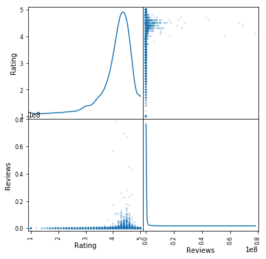

```python
# Scatter Matrix Plot
from pandas.plotting import scatter_matrix
scatter_matrix(df, alpha=0.2, figsize=(6, 6), diagonal='kde');
```

### // scatter

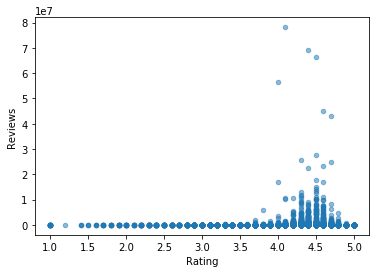

```python
# You can pass other keywords supported by matplotlib scatter.
df.plot.scatter(x='Rating', y='Reviews', alpha=0.5);
```

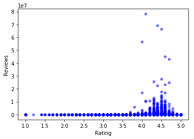

```python
df.plot(kind='scatter', x='Rating', y='Reviews', alpha=0.5, color='b');
```

```python
df.plot(kind='scatter', x='Rating', y='Reviews', alpha=0.5, color='b');
```

[output not shown]

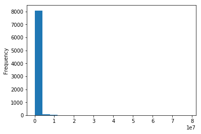

```python
df.Reviews.plot(kind='hist', bins=20);
```

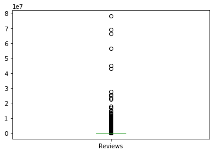

```python
df.Reviews.plot(kind='box');
```

```python
df.query('Reviews > 50000000')
```

|  | App | Rating | Reviews | Installs | Type | Price | Genres |
| --- | --- | --- | --- | --- | --- | --- | --- |
| 336 | WhatsApp Messenger | 4.4 | 69119316 | 1,000,000,000+ | Free | 0 | Communication |
| 382 | Messenger – Text and Video Chat for Free | 4.0 | 56646578 | 1,000,000,000+ | Free | 0 | Communication |
| 2604 | Instagram | 4.5 | 66577446 | 1,000,000,000+ | Free | 0 | Social |
| 2544 | Facebook | 4.1 | 78158306 | 1,000,000,000+ | Free | 0 | Social |

### // histgram

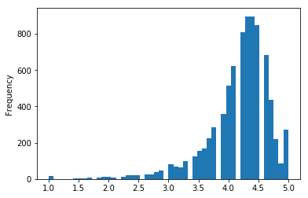

```python
df.Rating.plot.hist(bins=50);
```

```python
df.sample()
```

|  | App | Rating | Reviews | Installs | Type | Price | Genres |
| --- | --- | --- | --- | --- | --- | --- | --- |
| 1294 | Recipes for hair and face tried | 4.5 | 1203 | 500,000+ | Free | 0 | Health & Fitness |

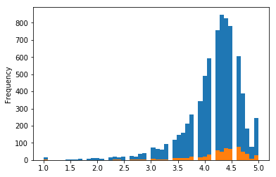

```python
df.groupby('Type')['Rating'].plot.hist(bins=50);
```

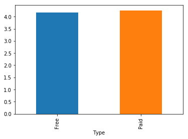

```python
df.groupby('Type')['Rating'].mean().plot.bar();
```

```
Price
$0.99      [[AxesSubplot(0.125,0.125;0.336957x0.755), Axe...
$1.00      [[AxesSubplot(0.125,0.125;0.336957x0.755), Axe...
$1.20      [[AxesSubplot(0.125,0.125;0.336957x0.755), Axe...
$1.29      [[AxesSubplot(0.125,0.125;0.336957x0.755), Axe...
$1.49      [[AxesSubplot(0.125,0.125;0.336957x0.755), Axe...
$1.50      [[AxesSubplot(0.125,0.125;0.336957x0.755), Axe...
$1.59      [[AxesSubplot(0.125,0.125;0.336957x0.755), Axe...
$1.61      [[AxesSubplot(0.125,0.125;0.336957x0.755), Axe...
$1.70      [[AxesSubplot(0.125,0.125;0.336957x0.755), Axe...
$1.75      [[AxesSubplot(0.125,0.125;0.336957x0.755), Axe...
$1.76      [[AxesSubplot(0.125,0.125;0.336957x0.755), Axe...
$1.97      [[AxesSubplot(0.125,0.125;0.336957x0.755), Axe...
$1.99      [[AxesSubplot(0.125,0.125;0.336957x0.755), Axe...
$10.00     [[AxesSubplot(0.125,0.125;0.336957x0.755), Axe...
$10.99     [[AxesSubplot(0.125,0.125;0.336957x0.755), Axe...
$11.99     [[AxesSubplot(0.125,0.125;0.336957x0.755), Axe...
$12.99     [[AxesSubplot(0.125,0.125;0.336957x0.755), Axe...
$13.99     [[AxesSubplot(0.125,0.125;0.336957x0.755), Axe...
$14.00     [[AxesSubplot(0.125,0.125;0.336957x0.755), Axe...
$14.99     [[AxesSubplot(0.125,0.125;0.336957x0.755), Axe...
$15.46     [[AxesSubplot(0.125,0.125;0.336957x0.755), Axe...
$15.99     [[AxesSubplot(0.125,0.125;0.336957x0.755), Axe...
$16.99     [[AxesSubplot(0.125,0.125;0.336957x0.755), Axe...
$17.99     [[AxesSubplot(0.125,0.125;0.336957x0.755), Axe...
$18.99     [[AxesSubplot(0.125,0.125;0.336957x0.755), Axe...
$19.40     [[AxesSubplot(0.125,0.125;0.336957x0.755), Axe...
$19.99     [[AxesSubplot(0.125,0.125;0.336957x0.755), Axe...
$2.00      [[AxesSubplot(0.125,0.125;0.336957x0.755), Axe...
$2.49      [[AxesSubplot(0.125,0.125;0.336957x0.755), Axe...
$2.50      [[AxesSubplot(0.125,0.125;0.336957x0.755), Axe...
                                 ...
$3.88      [[AxesSubplot(0.125,0.125;0.336957x0.755), Axe...
$3.90      [[AxesSubplot(0.125,0.125;0.336957x0.755), Axe...
$3.95      [[AxesSubplot(0.125,0.125;0.336957x0.755), Axe...
$3.99      [[AxesSubplot(0.125,0.125;0.336957x0.755), Axe...
$33.99     [[AxesSubplot(0.125,0.125;0.336957x0.755), Axe...
$37.99     [[AxesSubplot(0.125,0.125;0.336957x0.755), Axe...
$379.99    [[AxesSubplot(0.125,0.125;0.336957x0.755), Axe...
$389.99    [[AxesSubplot(0.125,0.125;0.336957x0.755), Axe...
```

[output cut: 8 more lines]

```
$4.99      [[AxesSubplot(0.125,0.125;0.336957x0.755), Axe...
$400.00    [[AxesSubplot(0.125,0.125;0.336957x0.755), Axe...
$5.49      [[AxesSubplot(0.125,0.125;0.336957x0.755), Axe...
$5.99      [[AxesSubplot(0.125,0.125;0.336957x0.755), Axe...
$6.49      [[AxesSubplot(0.125,0.125;0.336957x0.755), Axe...
$6.99      [[AxesSubplot(0.125,0.125;0.336957x0.755), Axe...
$7.49      [[AxesSubplot(0.125,0.125;0.336957x0.755), Axe...
$7.99      [[AxesSubplot(0.125,0.125;0.336957x0.755), Axe...
$79.99     [[AxesSubplot(0.125,0.125;0.336957x0.755), Axe...
$8.49      [[AxesSubplot(0.125,0.125;0.336957x0.755), Axe...
$8.99      [[AxesSubplot(0.125,0.125;0.336957x0.755), Axe...
$9.00      [[AxesSubplot(0.125,0.125;0.336957x0.755), Axe...
$9.99      [[AxesSubplot(0.125,0.125;0.336957x0.755), Axe...
0          [[AxesSubplot(0.125,0.125;0.336957x0.755), Axe...
Length: 73, dtype: object
```

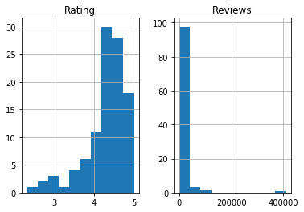

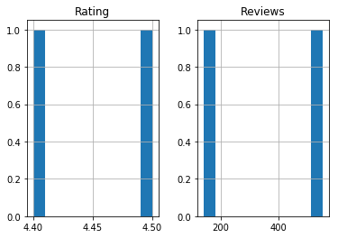

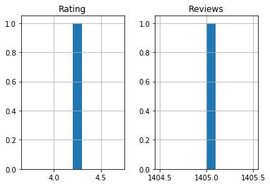

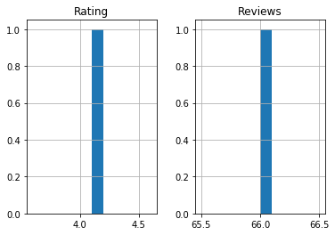

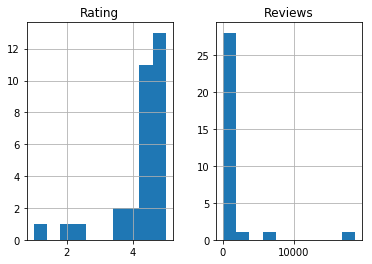

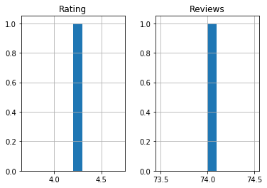

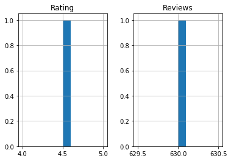

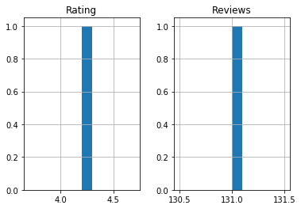

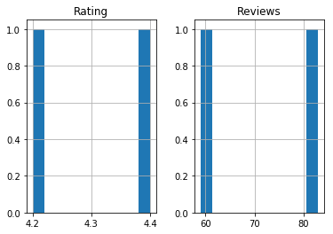

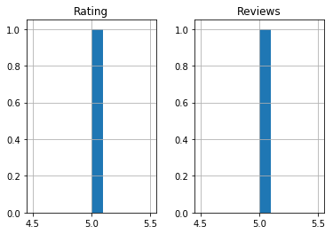

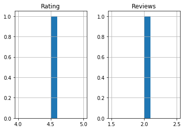

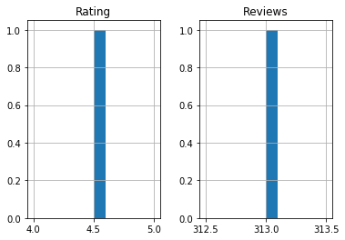

[61 more figures not shown]

```python
df.query('Type == "Paid"').groupby('Price').hist()
## goupby 将会输出每个分类的图, 比较琐碎
```

```python
df.Price.value_counts()[:10]
```

```
0        7592
$2.99     109
$0.99     104
$4.99      68
$1.99      59
$3.99      52
$1.49      31
$2.49      20
$5.99      14
$9.99      14
Name: Price, dtype: int64
```

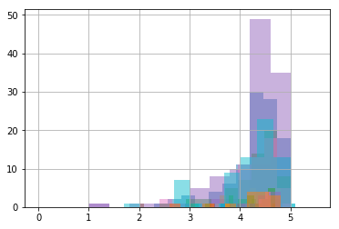

```python
df.query('Type == "Paid"').groupby('Price').Rating.hist(alpha=0.5);
### price 数据需要映射到比较整的数值范围进行展
```

### // bar plot

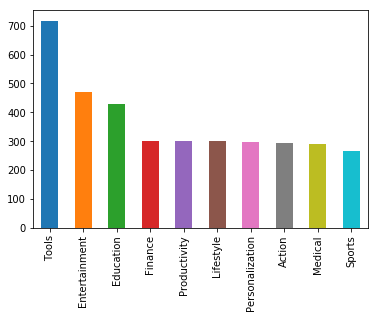

```python
df.Genres.value_counts()[:10].plot(kind='bar');
```

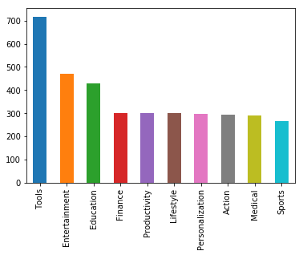

```python
df.Genres.value_counts()[:10].plot.bar();
## 两种方式输出一致, 看个人爱好
```

```python
df.sort_values(by=['Reviews'], ascending=False)[:10]
```

|  | App | Rating | Reviews | Installs | Type | Price | Genres |
| --- | --- | --- | --- | --- | --- | --- | --- |
| 2544 | Facebook | 4.1 | 78158306 | 1,000,000,000+ | Free | 0 | Social |
| 336 | WhatsApp Messenger | 4.4 | 69119316 | 1,000,000,000+ | Free | 0 | Communication |
| 2604 | Instagram | 4.5 | 66577446 | 1,000,000,000+ | Free | 0 | Social |
| 382 | Messenger – Text and Video Chat for Free | 4.0 | 56646578 | 1,000,000,000+ | Free | 0 | Communication |
| 1879 | Clash of Clans | 4.6 | 44893888 | 100,000,000+ | Free | 0 | Strategy |
| 4005 | Clean Master- Space Cleaner & Antivirus | 4.7 | 42916526 | 500,000,000+ | Free | 0 | Tools |
| 1872 | Subway Surfers | 4.5 | 27725352 | 1,000,000,000+ | Free | 0 | Arcade |
| 3665 | YouTube | 4.3 | 25655305 | 1,000,000,000+ | Free | 0 | Video Players & Editors |
| 7536 | Security Master - Antivirus, VPN, AppLock, Boo... | 4.7 | 24900999 | 500,000,000+ | Free | 0 | Tools |
| 1878 | Clash Royale | 4.6 | 23136735 | 100,000,000+ | Free | 0 | Strategy |

在数据的探索性分析中，请确保你对数据分析中的关键步骤和推理过程进行了记录。你可以自己插入code cell和markdown cell来组织你的报告。

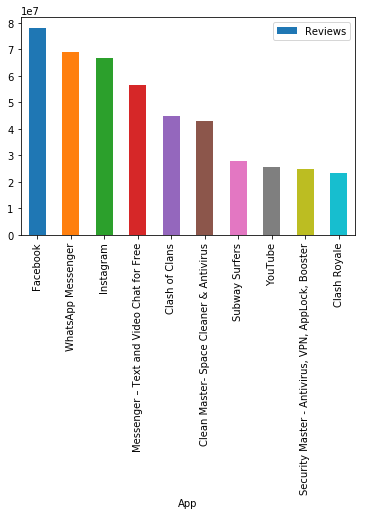

```python
df.sort_values(by=['Reviews'], ascending=False)[:10].plot.bar(x='App', y='Reviews');
```

# 得出结论

**问题**：上面的分析能够回答你提出的问题？通过这些分析你能够得出哪些结论？

### // A1. 下载分类最多的是什么类型的软件

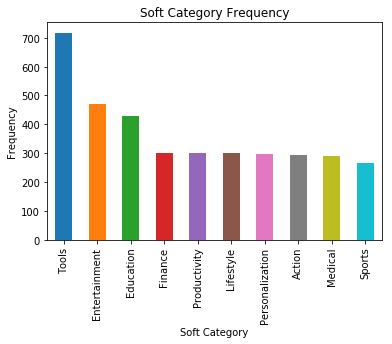

```python
df.Genres.value_counts()[:10].plot.bar()

plt.title('Soft Category Frequency')
plt.xlabel('Soft Category')
plt.ylabel('Frequency');
```

**A1 Insight:**

### // A2. 评论最多的是什么软件

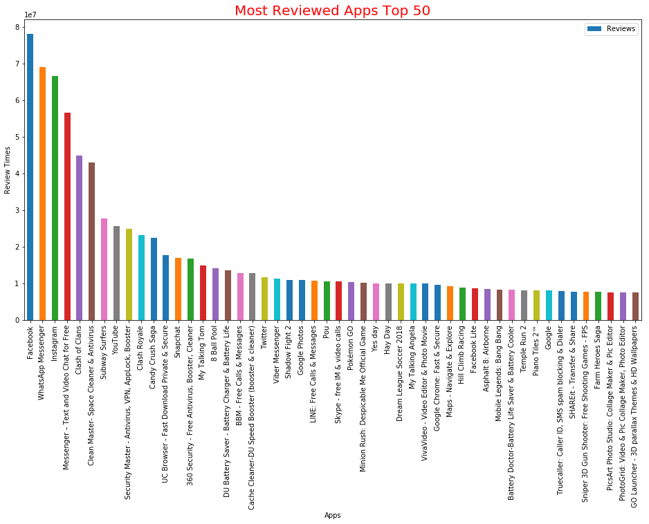

```python
df.sort_values(by=['Reviews'], ascending=False)[:50].plot.bar(x='App', y='Reviews', figsize=(16,8))

plt.title('Most Reviewed Apps Top 50', fontsize=20, color='r')
plt.xlabel('Apps')
plt.ylabel('Review Times')
# plt.legend(loc='best');
## 如果要区分 legend (比如按照 genres), 需要分组画图, 需要使用 matplotlib完成
```

**A2 Insight:**

### // A3. 免费软件和付费软件的对比

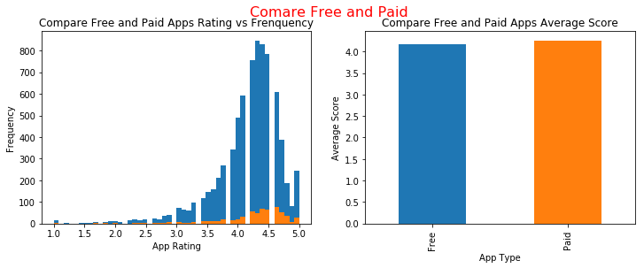

```python
fig = plt.figure(figsize=(12,4))
fig.suptitle('Comare Free and Paid', fontsize=16, color='r');


plt.subplot(1,2,1)
df.groupby('Type')['Rating'].plot.hist(bins=50)
plt.xlabel('App Rating')
plt.title('Compare Free and Paid Apps Rating vs Frenquency')
plt.subplot(1,2,2)
df.groupby('Type')['Rating'].mean().plot.bar()
plt.xlabel('App Type')
plt.ylabel('Average Score')
plt.title('Compare Free and Paid Apps Average Score');
# https://stackoverflow.com/questions/22483588/how-can-i-plot-separate-pandas-dataframes-as-subplots
```

**A3 Insight:**

- 免费软件数量占绝对优势
- 付费软件评分平均值略高
- 付费软件评分分布比免费软件更靠近右侧(评分高的一侧)

### // A4. 软件评分与Reviews数量有没有关系

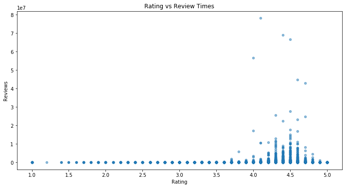

```python
df.plot.scatter(x='Rating', y='Reviews', alpha=0.5, figsize=(12,6))
plt.title('Rating vs Review Times');
```

**A4 Insight:**

# 反思

**问题**：在你的分析和总结过程中是否存在逻辑严谨。是否有改进的空间? 你可以从下面的一些角度进行思考：

1. 数据集是否完整，包含所有想要分析的数据？
2. 在对数据进行处理的时候，你的操作（例如删除/填充缺失值）是否可能影响结论？
3. 是否还有其他变量（本数据中没有）能够对你的分析有帮助？
4. 在得出结论时，你是否混淆了相关性和因果性？

**答案**：

- 数据集的质量不是特别完善,希望后续数据能够改善. 且 Featrue 并不是很多.
- 删除数量较多, 可能会影响样本分布并影响结果
- 如果能够看到程序的激活率(下载之后真正使用的)和使用频率能更有帮助
- 没有,A4只能得出相关性, 不能得出因果性(作为分析,不应给出因果性关系,只用相关性做描述).

恭喜你完成了此项目！这只是数据分析过程的一个样本：从生成问题、整理数据、探索数据到得出结论。在数据分析(进阶)纳米学位中，你将会学到更多高级的数据分析方法和技术，如果你感兴趣的话，我们鼓励你继续学习后续的课程，掌握更多的数据分析的高级技能！

> 若想与他人分享我们的分析结果，除了向他们提供 jupyter Notebook (.ipynb) 文件的副本外，我们还可以将 Notebook 输出导出为一种甚至那些未安装 Python 的人都能打开的形式。从左上方的“文件”菜单，前往“下载为”子菜单。然后你可以选择一个可以更普遍查看的格式，例如 HTML (.html) 。你可能需要额外软件包或软件来执行这些导出。